# Module 4/5 Project 1

2025-06-12

## Dataset for our Presentation and Analyses

We will use the **Sleep Health and Lifestyle Dataset** on Kaggle for our presentation and analyses.

I picked this dataset because:

- **Personal Relevance**: I tend to stay up and sleep late pretty often and sleep less than seven hours every school day
- **Professional Curiosity**: I am curious about how some parts, such as occupation or the amount of sleep, affect our health
- **Academic Interest**: I am interested in health-related topics whenever I do projects or analyses

## Dataset Quick Summary

Created by Laksika Tharmalingam, the **Sleep Health and Lifestyle Dataset** is a dataset from Kaggle that covers “a wide range of variables related to sleep and daily habits.”

- 374 rows, according to the CSV file
- 13 columns:
- Person ID, Gender, Age, Occupation
- Sleep Duration, Quality of Sleep, Physical Activity
- Stress Level, BMI Category, Blood Pressure
- Heart Rate, Daily Steps, Sleep Disorder

Link: https://www.kaggle.com/datasets/uom190346a/sleep-health-and-lifestyle-dataset

## Problems

**Occupation Impact by Sleep**: When dealing with stress, it could disrupt our sleep patterns, such as duration and quality. That applies to different occupations, giving some employees work-related stress and irregular schedules. Knowing which occupations are affected can inform workplace wellness policies.

**Question**: “Do certain occupations report significantly shorter sleep duration or low-quality scores?”

**BMI Category and Sleep Health**: While obesity is a known risk factor for sleep disorders, its relationship with perceived sleep quality remains understudied in everyday populations.

**Question**: “How does the BMI category correlate with self-reported sleep quality and stress levels?”

## Load Libraries

Now that we know the problems, we will load some libraries to get the tools required for the dataset analysis. I picked ggplot2, dplyr, and tidyr.

```r
# Loading libraries
library(ggplot2)
library(tidyr)
library(dplyr)
```

## Load CSV File

We load the CSV file from the dataset **Sleep_health_and_lifestyle_dataset.csv** and put it in the sleepData variable. That is where we get the rows, columns, and values we need for our analyses.

```r
# Loading the CSV file
sleepData = read.csv("Sleep_health_and_lifestyle_dataset.csv",
              header = TRUE)
```

## Check the Variables Summary

To check the loaded CSV file is in place, I use the summary function to view the variables and their information.

```r
# Checking that the CSV file is in place
summary(sleepData)
```

```
##    Person.ID         Gender               Age         Occupation
##  Min.   :  1.00   Length:374         Min.   :27.00   Length:374
##  1st Qu.: 94.25   Class :character   1st Qu.:35.25   Class :character
##  Median :187.50   Mode  :character   Median :43.00   Mode  :character
##  Mean   :187.50                      Mean   :42.18
##  3rd Qu.:280.75                      3rd Qu.:50.00
##  Max.   :374.00                      Max.   :59.00
##  Sleep.Duration  Quality.of.Sleep Physical.Activity.Level  Stress.Level
##  Min.   :5.800   Min.   :4.000    Min.   :30.00           Min.   :3.000
##  1st Qu.:6.400   1st Qu.:6.000    1st Qu.:45.00           1st Qu.:4.000
##  Median :7.200   Median :7.000    Median :60.00           Median :5.000
##  Mean   :7.132   Mean   :7.313    Mean   :59.17           Mean   :5.385
##  3rd Qu.:7.800   3rd Qu.:8.000    3rd Qu.:75.00           3rd Qu.:7.000
##  Max.   :8.500   Max.   :9.000    Max.   :90.00           Max.   :8.000
##  BMI.Category       Blood.Pressure       Heart.Rate     Daily.Steps
##  Length:374         Length:374         Min.   :65.00   Min.   : 3000
##  Class :character   Class :character   1st Qu.:68.00   1st Qu.: 5600
##  Mode  :character   Mode  :character   Median :70.00   Median : 7000
##                                        Mean   :70.17   Mean   : 6817
##                                        3rd Qu.:72.00   3rd Qu.: 8000
##                                        Max.   :86.00   Max.   :10000
##  Sleep.Disorder
##  Length:374
##  Class :character
##  Mode  :character
##
##
##
```

## Check the Variables Type

I use the glimpse function to see what variable types the columns are, and we see seven integers, five characters, and one double in those thirteen columns.

```r
# Checking the variable types
glimpse(sleepData)
```

```
## Rows: 374
## Columns: 13
## $ Person.ID               <int> 1, 2, 3, 4, 5, 6, 7, 8, 9, 10, 11, 12, 13, 14,…
## $ Gender                  <chr> "Male", "Male", "Male", "Male", "Male", "Male"…
## $ Age                     <int> 27, 28, 28, 28, 28, 28, 29, 29, 29, 29, 29, 29…
## $ Occupation              <chr> "Software Engineer", "Doctor", "Doctor", "Sale…
## $ Sleep.Duration          <dbl> 6.1, 6.2, 6.2, 5.9, 5.9, 5.9, 6.3, 7.8, 7.8, 7…
## $ Quality.of.Sleep        <int> 6, 6, 6, 4, 4, 4, 6, 7, 7, 7, 6, 7, 6, 6, 6, 6…
## $ Physical.Activity.Level <int> 42, 60, 60, 30, 30, 30, 40, 75, 75, 75, 30, 75…
## $ Stress.Level            <int> 6, 8, 8, 8, 8, 8, 7, 6, 6, 6, 8, 6, 8, 8, 8, 8…
## $ BMI.Category            <chr> "Overweight", "Normal", "Normal", "Obese", "Ob…
## $ Blood.Pressure          <chr> "126/83", "125/80", "125/80", "140/90", "140/9…
## $ Heart.Rate              <int> 77, 75, 75, 85, 85, 85, 82, 70, 70, 70, 70, 70…
## $ Daily.Steps             <int> 4200, 10000, 10000, 3000, 3000, 3000, 3500, 80…
## $ Sleep.Disorder          <chr> "None", "None", "None", "Sleep Apnea", "Sleep …
```

## Cleaning and Converting Data

We clean the file from the missing values and convert some columns to different variable types.

```r
# Check if the CSV file have missing values
sum(is.na(sleepData))
```

```
## [1] 0
```

We need to switch the columns from categorical to factorial using the mutate function. That way, it is easier to do analysis testing, such as visualization.

```r
# Converting categorical variables to factors
sleepData = sleepData %>%
  mutate(
    Occupation = as.factor(Occupation),
    BMI.Category = as.factor(BMI.Category))
```

## Occupation Impact by Sleep

We want to know if certain occupations report significantly shorter sleep duration or low-quality scores.

```r
# Creating the occSleep variable
occSleep = sleepData %>%
  group_by(Occupation) %>%
  summarize(
    avgDuration = mean(Sleep.Duration),
    avgQuality = mean(Quality.of.Sleep)) %>%
  arrange(avgDuration)
```

## Occupation Impact by Sleep (cont.)

We finished adding some stuff for the occSleep variable, and it is time to create a barplot graph for the chosen columns. We use ggplot to make a graph and put the occSleep variable to extract data we made earlier.

```r
# Average Sleep Duration Graph
ggplot(occSleep, aes(x = reorder(Occupation, avgDuration),
                     y = avgDuration)) + geom_col(fill = "red") +
  coord_flip() +
  labs(title = "Average Sleep Duration by Occupation", x = "",
       y = "Hours") + theme_minimal()
```

We also made a graph for Average Sleep Quality, similar to what we did.

```r
# Average Sleep Quality Graph
ggplot(occSleep, aes(x = reorder(Occupation, avgQuality),
                     y = avgQuality)) + geom_col(fill = "blue") +
  coord_flip() +
  labs(title = "Average Sleep Quality by Occupation", x = "",
       y = "Sleep Quality from 1-10") + theme_minimal()
```

## Occupation Impact by Sleep Graphs

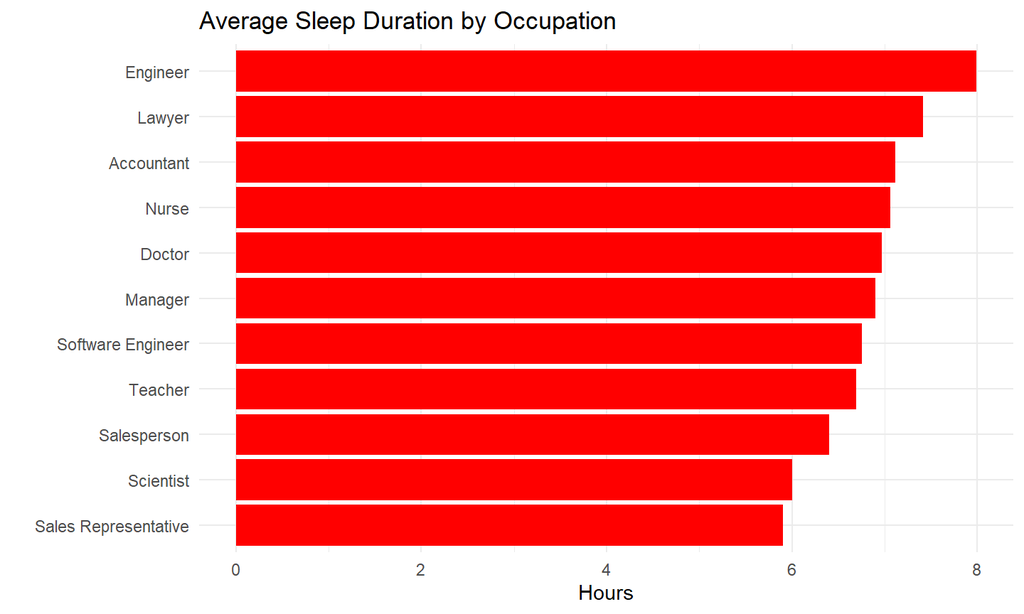

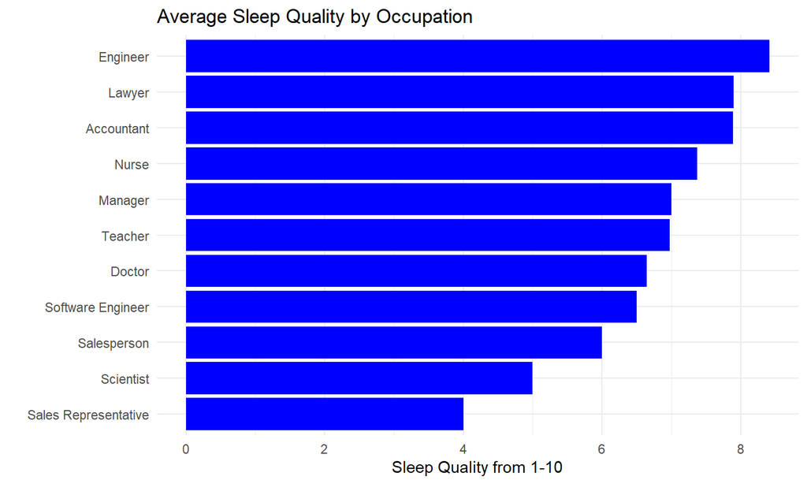

## BMI Category and Sleep Health

We want to know how the BMI category correlates with self-reported sleep quality and stress levels. That is like the first problem, except we do not create a custom variable. Also, instead of a barplot, we use a boxplot graph and add a legend.

```r
# Sleep Quality Graph
ggplot(sleepData, aes(x = BMI.Category, y = Quality.of.Sleep)) +
  geom_boxplot(aes(fill = BMI.Category)) +
  labs(title = "Sleep Quality by BMI Category", x = "BMI Category",
       y = "Sleep Quality (1-10)", fill = "BMI Category") +
  theme_minimal()
```

```r
# Stress Level Graph
ggplot(sleepData, aes(x = BMI.Category, y = Stress.Level)) +
  geom_boxplot(aes(fill = BMI.Category)) +
  labs(title = "Stress Level by BMI Category", x = "BMI Category",
       y = "Stress Level (1-10)", fill = "BMI Category") +
  theme_minimal()
```

## BMI Category and Sleep Health Graphs

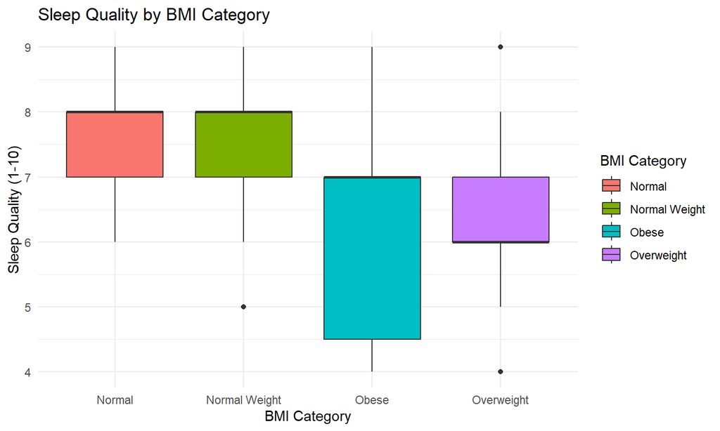

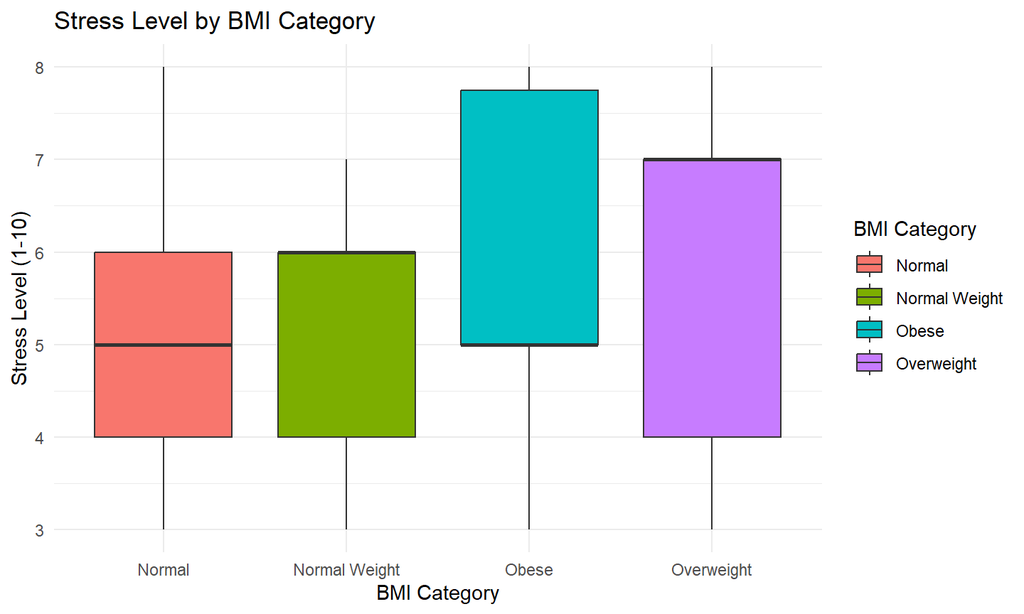

## Conclusion

### Occupation Impact on Sleep

- Engineers have the highest sleep duration (8 hours) and best sleep quality (8.5/10)
- Sales Representatives have the lowest sleep duration (around 5.8 hours) and poorest sleep quality (4/10), suggesting high work-related stress
- Actionable insight: High-stress occupations, such as sales or scientists, may benefit from workplace wellness programs to improve sleep

## Limitations and Future Work

### Limitations

- Possible biases in self-reported data
- Uneven sample size per occupation and BMI group

### Future Work

- Investigate specific interventions
- Examples: Flexible schedules for nurses, stress workshops for the sales team, etc.